# Homework 3

PSTAT 231

Anna Kazachka

April 19, 2022

# Classification

## Question 1

**Split the data, stratifying on the outcome variable, survived. You should choose the proportions to split the data into. Verify that the training and testing data sets have the appropriate number of observations. Take a look at the training data and note any potential issues, such as missing data.**

```r
tit <- read_csv("titanic.csv")
tit$survived <- as.factor(tit$survived)
set.seed(777)
tit_split <- initial_split(tit, prop = 0.80, strata = survived)
tit_train <- training(tit_split)
tit_test <- testing(tit_split)
tit_train
```

```
## # A tibble: 712 × 12
##    passenger_id survived pclass name      sex     age sib_sp parch ticket   fare
##           <dbl> <fct>     <dbl> <chr>     <chr> <dbl>  <dbl> <dbl> <chr>   <dbl>
##  1            5 No            3 Allen, M… male     35      0     0 373450   8.05
##  2            7 No            1 McCarthy… male     54      0     0 17463   51.9
##  3            8 No            3 Palsson,… male      2      3     1 349909  21.1
##  4           13 No            3 Saunderc… male     20      0     0 A/5. …   8.05
##  5           14 No            3 Andersso… male     39      1     5 347082  31.3
##  6           15 No            3 Vestrom,… fema…    14      0     0 350406   7.85
##  7           17 No            3 Rice, Ma… male      2      4     1 382652  29.1
##  8           25 No            3 Palsson,… fema…     8      3     1 349909  21.1
##  9           27 No            3 Emir, Mr… male     NA      0     0 2631     7.22
## 10           28 No            1 Fortune,… male     19      3     2 19950  263
## # … with 702 more rows, and 2 more variables: cabin <chr>, embarked <chr>
```

In the training set there is a lot of missing data in the cabin column and some missing values in the age column.

**Why is it a good idea to use stratified sampling for this data?**

It is a good idea to use stratified sampling for this data because there is a lot more people who have died than survived and in order to maintain the ratio it must be stratified.

## Question 2

**Using the training data set, explore/describe the distribution of the outcome variable survived.**

The distribution of the outcome variable survived is a lot smaller than that of those who have died.

## Question 3

**Using the training data set, create a correlation matrix of all continuous variables. Create a visualization of the matrix, and describe any patterns you see. Are any predictors correlated with each other? Which ones, and in which direction?**

```r
num.tit <- tit_train %>% select_if(is.numeric)
cor_num.tit <- num.tit %>% correlate()
```

```
##
## Correlation method: 'pearson'
## Missing treated using: 'pairwise.complete.obs'
```

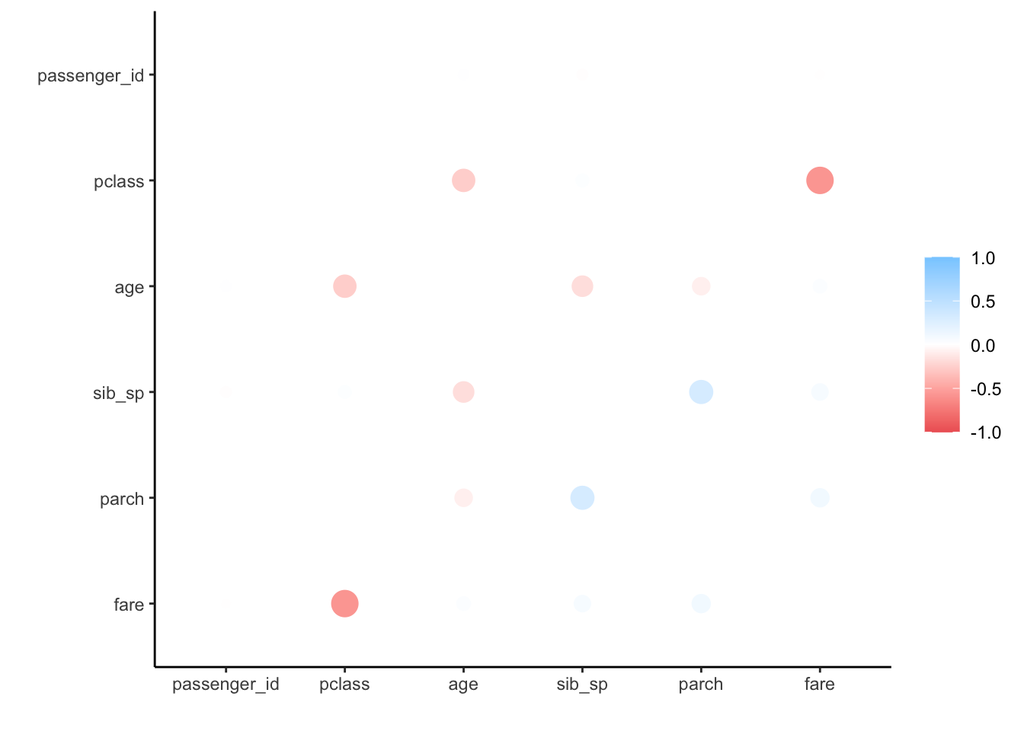

```r
rplot(cor_num.tit)
```

Fare a pclass seem to be greatly negatively correlated.

## Question 4

**Using the training data, create a recipe predicting the outcome variable survived. Include the following predictors: ticket class, sex, age, number of siblings or spouses aboard, number of parents or children aboard, and passenger fare.**

**Recall that there were missing values for age. To deal with this, add an imputation step using step_impute_linear(). Next, use step_dummy() to dummy encode categorical predictors. Finally, include interactions between:**

**Sex and passenger fare, and Age and passenger fare.**

**You’ll need to investigate the tidymodels documentation to find the appropriate step functions to use.**

```r
tit_recipe <- recipe(survived ~ pclass + sex + age + sib_sp + parch + fare,
                     data = tit_train) %>%
  step_impute_linear(age) %>%
  step_dummy(all_nominal_predictors()) %>%
  step_interact(~ starts_with("sex"):fare) %>%
  step_interact(~ age:fare)
```

## Question 5

**Specify a logistic regression model for classification using the “glm” engine. Then create a workflow. Add your model and the appropriate recipe. Finally, use fit() to apply your workflow to the training data.**

**Hint: Make sure to store the results of fit(). You’ll need them later on.**

```r
log_reg <- logistic_reg() %>% set_engine("glm") %>% set_mode("classification")
log_wkflow <- workflow() %>% add_model(log_reg) %>% add_recipe(tit_recipe)
log_fit <- fit(log_wkflow, tit_train)
```

## Question 6

**Repeat Question 5, but this time specify a linear discriminant analysis model for classification using the “MASS” engine.**

```r
lda_mod <- discrim_linear() %>% set_mode("classification") %>% set_engine("MASS")
lda_wkflow <- workflow() %>% add_model(lda_mod) %>% add_recipe(tit_recipe)
lda_fit <- fit(lda_wkflow, tit_train)
```

## Question 7

**Repeat Question 5, but this time specify a quadratic discriminant analysis model for classification using the “MASS” engine.**

```r
qda_mod <- discrim_quad() %>%
  set_mode("classification") %>%
  set_engine("MASS")

qda_wkflow <- workflow() %>%
  add_model(qda_mod) %>%
  add_recipe(tit_recipe)

qda_fit <- fit(qda_wkflow, tit_train)
```

## Question 8

**Repeat Question 5, but this time specify a naive Bayes model for classification using the “klaR” engine. Set the usekernel argument to FALSE.**

```r
nb_mod <- naive_Bayes() %>%
  set_mode("classification") %>%
  set_engine("klaR") %>%
  set_args(usekernel = FALSE)

nb_wkflow <- workflow() %>%
  add_model(nb_mod) %>%
  add_recipe(tit_recipe)
nb_fit <- fit(nb_wkflow, tit_train)
```

## Question 9

**Now you’ve fit four different models to your training data. Use predict() and bind_cols() to generate predictions using each of these 4 models and your training data. Then use the accuracy metric to assess the performance of each of the four models.**

```r
predict(log_fit, new_data = tit_train, type = "prob")
```

```
## # A tibble: 712 × 2
##    .pred_No .pred_Yes
##       <dbl>     <dbl>
##  1    0.927    0.0734
##  2    0.681    0.319
##  3    0.893    0.107
##  4    0.841    0.159
##  5    0.975    0.0247
##  6    0.230    0.770
##  7    0.934    0.0659
##  8    0.454    0.546
##  9    0.894    0.106
## 10    0.934    0.0657
## # … with 702 more rows
```

```r
log_reg_acc <- augment(log_fit, new_data = tit_train) %>%
  accuracy(truth = survived, estimate = .pred_class)
log_reg_acc
```

```
## # A tibble: 1 × 3
##   .metric  .estimator .estimate
##   <chr>    <chr>          <dbl>
## 1 accuracy binary         0.815
```

```r
predict(lda_fit, new_data = tit_train, type = "prob")
```

```
## # A tibble: 712 × 2
##    .pred_No .pred_Yes
##       <dbl>     <dbl>
##  1    0.952    0.0482
##  2    0.740    0.260
##  3    0.924    0.0762
##  4    0.895    0.105
##  5    0.985    0.0153
##  6    0.180    0.820
##  7    0.951    0.0492
##  8    0.363    0.637
##  9    0.930    0.0696
## 10    0.927    0.0729
## # … with 702 more rows
```

```r
lda_acc <- augment(lda_fit, new_data = tit_train) %>%
  accuracy(truth = survived, estimate = .pred_class)
lda_acc
```

```
## # A tibble: 1 × 3
##   .metric  .estimator .estimate
##   <chr>    <chr>          <dbl>
## 1 accuracy binary         0.796
```

```r
predict(qda_fit, new_data = tit_train, type = "prob")
```

```
## # A tibble: 712 × 2
##    .pred_No .pred_Yes
##       <dbl>     <dbl>
##  1    0.989  1.14e- 2
##  2    0.895  1.05e- 1
##  3    0.999  5.47e- 4
##  4    0.971  2.90e- 2
##  5    1.00   3.37e- 5
##  6    0.203  7.97e- 1
##  7    1.00   5.40e- 6
##  8    0.989  1.09e- 2
##  9    0.983  1.67e- 2
## 10    1      1.86e-18
## # … with 702 more rows
```

```r
qda_acc <- augment(qda_fit, new_data = tit_train) %>%
  accuracy(truth = survived, estimate = .pred_class)
qda_acc
```

```
## # A tibble: 1 × 3
##   .metric  .estimator .estimate
##   <chr>    <chr>          <dbl>
## 1 accuracy binary         0.803
```

```r
predict(nb_fit, new_data = tit_train, type = "prob")
```

```
## # A tibble: 712 × 2
##    .pred_No .pred_Yes
##       <dbl>     <dbl>
##  1    0.936 0.0638
##  2    0.544 0.456
##  3    0.999 0.00140
##  4    0.926 0.0740
##  5    0.999 0.000727
##  6    0.265 0.735
##  7    1.00  0.0000186
##  8    0.959 0.0406
##  9    0.933 0.0675
## 10    1.00  0.0000134
## # … with 702 more rows
```

```r
nb_acc <- augment(nb_fit, new_data = tit_train) %>%
  accuracy(truth = survived, estimate = .pred_class)
nb_acc
```

```
## # A tibble: 1 × 3
##   .metric  .estimator .estimate
##   <chr>    <chr>          <dbl>
## 1 accuracy binary         0.787
```

**Which model achieved the highest accuracy on the training data?**

```r
accuracies <- c(log_reg_acc$.estimate, lda_acc$.estimate,
                nb_acc$.estimate, qda_acc$.estimate)
models <- c("Logistic Regression", "LDA", "Naive Bayes", "QDA")
results <- tibble(accuracies = accuracies, models = models)
results %>% arrange(-accuracies)
```

```
## # A tibble: 4 × 2
##   accuracies models
##        <dbl> <chr>
## 1      0.815 Logistic Regression
## 2      0.803 QDA
## 3      0.796 LDA
## 4      0.787 Naive Bayes
```

Logistic Regression achieved the highest accuracy.

## Question 10

**Fit the model with the highest training accuracy to the testing data. Report the accuracy of the model on the testing data.**

```r
predict(log_fit, new_data = tit_test, type = "prob")
```

```
## # A tibble: 179 × 2
##    .pred_No .pred_Yes
##       <dbl>     <dbl>
##  1   0.898     0.102
##  2   0.0739    0.926
##  3   0.894     0.106
##  4   0.539     0.461
##  5   0.774     0.226
##  6   0.241     0.759
##  7   0.391     0.609
##  8   0.714     0.286
##  9   0.365     0.635
## 10   0.955     0.0453
## # … with 169 more rows
```

```r
log_acc_test <- augment(log_fit, new_data = tit_test) %>%
  accuracy(truth = survived, estimate = .pred_class)
log_acc_test
```

```
## # A tibble: 1 × 3
##   .metric  .estimator .estimate
##   <chr>    <chr>          <dbl>
## 1 accuracy binary         0.844
```

**Again using the testing data, create a confusion matrix and visualize it. Plot an ROC curve and calculate the area under it (AUC).**

```r
augment(log_fit, new_data = tit_test) %>%
  conf_mat(truth = survived, estimate = .pred_class)
```

```
##           Truth
## Prediction  No Yes
##        No  100  18
##        Yes  10  51
```

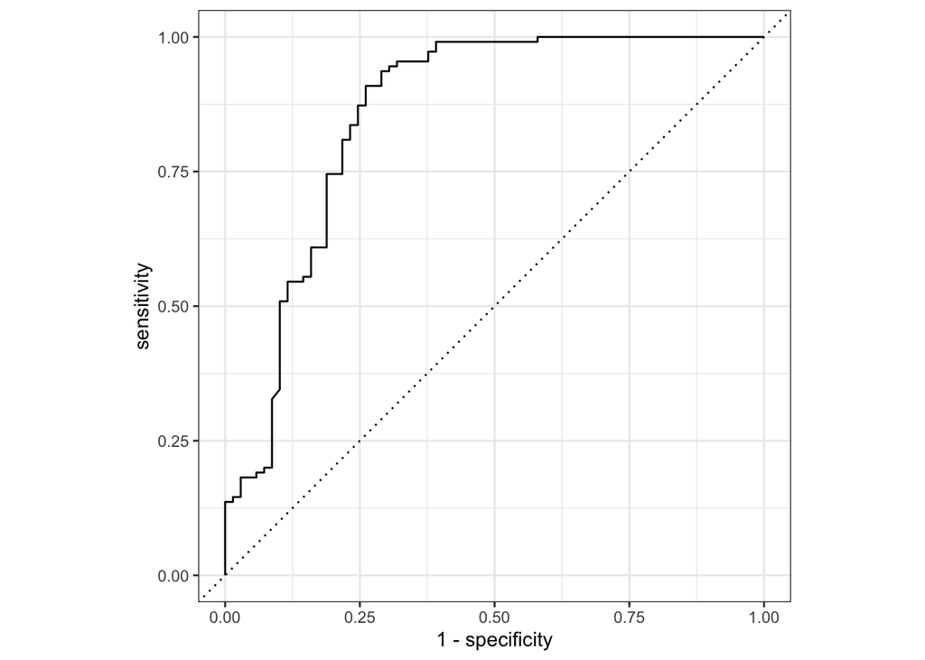

```r
augment(log_fit, new_data = tit_test) %>%
  roc_curve(survived, .pred_No) %>%
  autoplot()
```

**How did the model perform? Compare its training and testing accuracies. If the values differ, why do you think this is so?**

# 231

**In a binary classification problem, let p represent the probability of class label 1, which implies that 1−p represents the probability of class label 0. The logistic function (also called the “inverse logit”) is the cumulative distribution function of the logistic distribution, which maps a real number z to the open interval (0,1).**

## Question 11

**Given that: $p(z)=\frac{e^z}{1+e^z}$**

**Prove that the inverse of a logistic function is indeed the logit function: $z(p)=ln(\frac{p}{1−p})$**

$p(z)=\frac{e^z}{1+e^z} \rightarrow$ $e^z=p(1+e^z) \rightarrow$ $e^z=p+pe^z \rightarrow$ $p = e^z-pe^z = e^z(1-p) \rightarrow$ $e^z = \frac{p}{1-p} \rightarrow$ $ln(e^z)=ln(\frac{p}{1-p}) \rightarrow$ $z=ln(\frac{p}{1-p}) \rightarrow z(p)=ln(\frac{p}{1-p})$

## Question 12

**Assume that $z=\beta_0+\beta_1x_1$ and $p=logistic(z)$. How do the odds of the outcome change if you increase $x_1$ by two? Demonstrate this.**

Increasing $x$ by two means that the odds are multiplied by $(e^\beta_1)^2$.

**Assume now that $\beta_1$ is negative. What value does $p$ approach as $x_1$ approaches $\infty$?**

We have $p(z)=\frac{e^z}{1+e^z}$ and that $\beta_1<0$ and $x_1 \rightarrow \infty$. As $x_1 \rightarrow \infty$ the numerator,$e^z$, will continually get smaller while the denominator, $1+e^z$, will approach 1. Thus, $p$ will approach 0.

**What value does $p$ approach as $x_1$ approaches $-\infty$?**

We have $p(z)=\frac{e^z}{1+e^z}$ and that $\beta_1<0$ and $x_1 \rightarrow -\infty$. As $x_1 \rightarrow -\infty$ the numerator,$e^z$, will continually get larger and the denominator, $1+e^z$, also increases. So, as the both increase the ratio will get closer to 1 to 1. Thus, $p$ will approach 1.